# EDA

## **Exploratory Data Analysis Project**

### **Phase 1: Data Exploration & Initial Assessment**

```python
# importing libraries

import numpy as np
import pandas as pd


import matplotlib.pyplot as plt
import seaborn as sns
import missingno as msn
```

### **About the Data Set:**

**This project analyzes air quality data from the ISPU (Air Pollution Standard Index) dataset to understand pollution levels, patterns, and variations in DKI Jakarta. Through systematic exploratory data analysis (EDA), the study investigates relationships among major air pollutants, detects trends and extreme pollution events, and assesses how different pollutant concentrations influence overall air-quality categories.**

**By applying statistical analysis and visualization techniques, the project uncovers meaningful insights into air pollution behavior and its potential health implications. The results support effective environmental monitoring and provide a strong foundation for building predictive models and data-driven strategies for air-quality management.**

##### **1).Load the dataset**

- **pandas.read_csv() is a function in the Pandas library used to load data from a CSV (Comma Separated Values) file into a DataFrame.**

```python
# Loading the data set

df = pd.read_csv(r"ispu_dki_all.csv")
```

```python
df
```

|  | tanggal | stasiun | pm25 | pm10 | so2 | co | o3 | no2 | max | critical | categori |
| --- | --- | --- | --- | --- | --- | --- | --- | --- | --- | --- | --- |
| 0 | 2010-01-01 | DKI1 (Bunderan HI) | NaN | 60.0 | 4.0 | 73.0 | 27.0 | 14.0 | 73.0 | CO | SEDANG |
| 1 | 2010-01-02 | DKI1 (Bunderan HI) | NaN | 32.0 | 2.0 | 16.0 | 33.0 | 9.0 | 33.0 | O3 | BAIK |
| 2 | 2010-01-03 | DKI1 (Bunderan HI) | NaN | 27.0 | 2.0 | 19.0 | 20.0 | 9.0 | 27.0 | PM10 | BAIK |
| 3 | 2010-01-04 | DKI1 (Bunderan HI) | NaN | 22.0 | 2.0 | 16.0 | 15.0 | 6.0 | 22.0 | PM10 | BAIK |
| 4 | 2010-01-05 | DKI1 (Bunderan HI) | NaN | 25.0 | 2.0 | 17.0 | 15.0 | 8.0 | 25.0 | PM10 | BAIK |
| ... | ... | ... | ... | ... | ... | ... | ... | ... | ... | ... | ... |
| 5533 | 2025-02-24 | DKI3 (Jagakarsa) | 70.0 | 45.0 | 52.0 | 18.0 | 19.0 | 40.0 | 70.0 | PM25 | SEDANG |
| 5534 | 2025-02-25 | DKI5 (Kebon Jeruk) | 75.0 | 18.0 | 28.0 | 13.0 | 25.0 | 4.0 | 75.0 | PM25 | SEDANG |
| 5535 | 2025-02-26 | DKI3 (Jagakarsa) | 65.0 | 46.0 | 57.0 | 11.0 | 11.0 | 51.0 | 65.0 | PM25 | SEDANG |
| 5536 | 2025-02-27 | DKI5 (Kebon Jeruk) | 111.0 | 29.0 | 24.0 | 21.0 | 34.0 | 8.0 | 111.0 | PM25 | TIDAK SEHAT |
| 5537 | 2025-02-28 | DKI5 (Kebon Jeruk) | 71.0 | 20.0 | 24.0 | 9.0 | 31.0 | 6.0 | 71.0 | PM25 | SEDANG |

5538 rows × 11 columns

##### **2).View sample data**

- **After loading your dataset with pandas.read_csv(), you can use the .head() and .tail() function to view the first and last 5 rows of the DataFrame.**

```python
df.head()
```

|  | tanggal | stasiun | pm25 | pm10 | so2 | co | o3 | no2 | max | critical | categori |
| --- | --- | --- | --- | --- | --- | --- | --- | --- | --- | --- | --- |
| 0 | 2010-01-01 | DKI1 (Bunderan HI) | NaN | 60.0 | 4.0 | 73.0 | 27.0 | 14.0 | 73.0 | CO | SEDANG |
| 1 | 2010-01-02 | DKI1 (Bunderan HI) | NaN | 32.0 | 2.0 | 16.0 | 33.0 | 9.0 | 33.0 | O3 | BAIK |
| 2 | 2010-01-03 | DKI1 (Bunderan HI) | NaN | 27.0 | 2.0 | 19.0 | 20.0 | 9.0 | 27.0 | PM10 | BAIK |
| 3 | 2010-01-04 | DKI1 (Bunderan HI) | NaN | 22.0 | 2.0 | 16.0 | 15.0 | 6.0 | 22.0 | PM10 | BAIK |
| 4 | 2010-01-05 | DKI1 (Bunderan HI) | NaN | 25.0 | 2.0 | 17.0 | 15.0 | 8.0 | 25.0 | PM10 | BAIK |

```python
df.tail()
```

|  | tanggal | stasiun | pm25 | pm10 | so2 | co | o3 | no2 | max | critical | categori |
| --- | --- | --- | --- | --- | --- | --- | --- | --- | --- | --- | --- |
| 5533 | 2025-02-24 | DKI3 (Jagakarsa) | 70.0 | 45.0 | 52.0 | 18.0 | 19.0 | 40.0 | 70.0 | PM25 | SEDANG |
| 5534 | 2025-02-25 | DKI5 (Kebon Jeruk) | 75.0 | 18.0 | 28.0 | 13.0 | 25.0 | 4.0 | 75.0 | PM25 | SEDANG |
| 5535 | 2025-02-26 | DKI3 (Jagakarsa) | 65.0 | 46.0 | 57.0 | 11.0 | 11.0 | 51.0 | 65.0 | PM25 | SEDANG |
| 5536 | 2025-02-27 | DKI5 (Kebon Jeruk) | 111.0 | 29.0 | 24.0 | 21.0 | 34.0 | 8.0 | 111.0 | PM25 | TIDAK SEHAT |
| 5537 | 2025-02-28 | DKI5 (Kebon Jeruk) | 71.0 | 20.0 | 24.0 | 9.0 | 31.0 | 6.0 | 71.0 | PM25 | SEDANG |

- **By observing and examining the dataset, it is clear that some column names are in Indonesian, so they were translated into English to improve clarity and consistency for analysis.**

```python
df = df.rename(columns={
    'tanggal':'Date',
    'stasiun':'station',
    'categori':'Category'})
```

```python
df
```

|  | Date | station | pm25 | pm10 | so2 | co | o3 | no2 | max | critical | Category |
| --- | --- | --- | --- | --- | --- | --- | --- | --- | --- | --- | --- |
| 0 | 2010-01-01 | DKI1 (Bunderan HI) | NaN | 60.0 | 4.0 | 73.0 | 27.0 | 14.0 | 73.0 | CO | SEDANG |
| 1 | 2010-01-02 | DKI1 (Bunderan HI) | NaN | 32.0 | 2.0 | 16.0 | 33.0 | 9.0 | 33.0 | O3 | BAIK |
| 2 | 2010-01-03 | DKI1 (Bunderan HI) | NaN | 27.0 | 2.0 | 19.0 | 20.0 | 9.0 | 27.0 | PM10 | BAIK |
| 3 | 2010-01-04 | DKI1 (Bunderan HI) | NaN | 22.0 | 2.0 | 16.0 | 15.0 | 6.0 | 22.0 | PM10 | BAIK |
| 4 | 2010-01-05 | DKI1 (Bunderan HI) | NaN | 25.0 | 2.0 | 17.0 | 15.0 | 8.0 | 25.0 | PM10 | BAIK |
| ... | ... | ... | ... | ... | ... | ... | ... | ... | ... | ... | ... |
| 5533 | 2025-02-24 | DKI3 (Jagakarsa) | 70.0 | 45.0 | 52.0 | 18.0 | 19.0 | 40.0 | 70.0 | PM25 | SEDANG |
| 5534 | 2025-02-25 | DKI5 (Kebon Jeruk) | 75.0 | 18.0 | 28.0 | 13.0 | 25.0 | 4.0 | 75.0 | PM25 | SEDANG |
| 5535 | 2025-02-26 | DKI3 (Jagakarsa) | 65.0 | 46.0 | 57.0 | 11.0 | 11.0 | 51.0 | 65.0 | PM25 | SEDANG |
| 5536 | 2025-02-27 | DKI5 (Kebon Jeruk) | 111.0 | 29.0 | 24.0 | 21.0 | 34.0 | 8.0 | 111.0 | PM25 | TIDAK SEHAT |
| 5537 | 2025-02-28 | DKI5 (Kebon Jeruk) | 71.0 | 20.0 | 24.0 | 9.0 | 31.0 | 6.0 | 71.0 | PM25 | SEDANG |

5538 rows × 11 columns

- **The Category column was converted from Indonesian to English to improve clarity, ensure consistency across the dataset, and make the classifications easier to interpret during analysis.**

```python
# Ensure Category column is string
df['Category'] = df['Category'].astype(str).str.strip()

translation_map = {
    'SEDANG': 'MODERATE',
    'BAIK': 'GOOD',
    'TIDAK SEHAT': 'UNHEALTHY',
    'SANGAT TIDAK SEHAT': 'VERY UNHEALTHY',
    'BERBAHAYA': 'HAZARDOUS'
}

df['Category_EN'] = df['Category'].map(translation_map)

df.head()
```

|  | Date | station | pm25 | pm10 | so2 | co | o3 | no2 | max | critical | Category | Category_EN |
| --- | --- | --- | --- | --- | --- | --- | --- | --- | --- | --- | --- | --- |
| 0 | 2010-01-01 | DKI1 (Bunderan HI) | NaN | 60.0 | 4.0 | 73.0 | 27.0 | 14.0 | 73.0 | CO | SEDANG | MODERATE |
| 1 | 2010-01-02 | DKI1 (Bunderan HI) | NaN | 32.0 | 2.0 | 16.0 | 33.0 | 9.0 | 33.0 | O3 | BAIK | GOOD |
| 2 | 2010-01-03 | DKI1 (Bunderan HI) | NaN | 27.0 | 2.0 | 19.0 | 20.0 | 9.0 | 27.0 | PM10 | BAIK | GOOD |
| 3 | 2010-01-04 | DKI1 (Bunderan HI) | NaN | 22.0 | 2.0 | 16.0 | 15.0 | 6.0 | 22.0 | PM10 | BAIK | GOOD |
| 4 | 2010-01-05 | DKI1 (Bunderan HI) | NaN | 25.0 | 2.0 | 17.0 | 15.0 | 8.0 | 25.0 | PM10 | BAIK | GOOD |

```python
df.drop(['Category'],axis = 1,inplace = True)
```

```python
df
```

|  | Date | station | pm25 | pm10 | so2 | co | o3 | no2 | max | critical | Category_EN |
| --- | --- | --- | --- | --- | --- | --- | --- | --- | --- | --- | --- |
| 0 | 2010-01-01 | DKI1 (Bunderan HI) | NaN | 60.0 | 4.0 | 73.0 | 27.0 | 14.0 | 73.0 | CO | MODERATE |
| 1 | 2010-01-02 | DKI1 (Bunderan HI) | NaN | 32.0 | 2.0 | 16.0 | 33.0 | 9.0 | 33.0 | O3 | GOOD |
| 2 | 2010-01-03 | DKI1 (Bunderan HI) | NaN | 27.0 | 2.0 | 19.0 | 20.0 | 9.0 | 27.0 | PM10 | GOOD |
| 3 | 2010-01-04 | DKI1 (Bunderan HI) | NaN | 22.0 | 2.0 | 16.0 | 15.0 | 6.0 | 22.0 | PM10 | GOOD |
| 4 | 2010-01-05 | DKI1 (Bunderan HI) | NaN | 25.0 | 2.0 | 17.0 | 15.0 | 8.0 | 25.0 | PM10 | GOOD |
| ... | ... | ... | ... | ... | ... | ... | ... | ... | ... | ... | ... |
| 5533 | 2025-02-24 | DKI3 (Jagakarsa) | 70.0 | 45.0 | 52.0 | 18.0 | 19.0 | 40.0 | 70.0 | PM25 | MODERATE |
| 5534 | 2025-02-25 | DKI5 (Kebon Jeruk) | 75.0 | 18.0 | 28.0 | 13.0 | 25.0 | 4.0 | 75.0 | PM25 | MODERATE |
| 5535 | 2025-02-26 | DKI3 (Jagakarsa) | 65.0 | 46.0 | 57.0 | 11.0 | 11.0 | 51.0 | 65.0 | PM25 | MODERATE |
| 5536 | 2025-02-27 | DKI5 (Kebon Jeruk) | 111.0 | 29.0 | 24.0 | 21.0 | 34.0 | 8.0 | 111.0 | PM25 | UNHEALTHY |
| 5537 | 2025-02-28 | DKI5 (Kebon Jeruk) | 71.0 | 20.0 | 24.0 | 9.0 | 31.0 | 6.0 | 71.0 | PM25 | MODERATE |

5538 rows × 11 columns

```python
df.rename({"Category_EN":"Category"},inplace = True,axis = 1)
```

```python
## Convert Date Columns to Datetime

df['Date'] = pd.to_datetime(df['Date'], errors='coerce')
```

```python
## Convert Categorical Columns to Category Type

df['Category'] = df['Category'].astype('category')
```

- **Date column were converted to datetime format and categorical fields, including Category, were cast to the ‘category’ datatype to ensure correct interpretation and efficient processing of the dataset.**

```python
df.dtypes
```

```
Date        datetime64[ns]
station             object
pm25               float64
pm10               float64
so2                float64
co                 float64
o3                 float64
no2                float64
max                float64
critical            object
Category          category
dtype: object
```

```python
df.head()
```

|  | Date | station | pm25 | pm10 | so2 | co | o3 | no2 | max | critical | Category |
| --- | --- | --- | --- | --- | --- | --- | --- | --- | --- | --- | --- |
| 0 | 2010-01-01 | DKI1 (Bunderan HI) | NaN | 60.0 | 4.0 | 73.0 | 27.0 | 14.0 | 73.0 | CO | MODERATE |
| 1 | 2010-01-02 | DKI1 (Bunderan HI) | NaN | 32.0 | 2.0 | 16.0 | 33.0 | 9.0 | 33.0 | O3 | GOOD |
| 2 | 2010-01-03 | DKI1 (Bunderan HI) | NaN | 27.0 | 2.0 | 19.0 | 20.0 | 9.0 | 27.0 | PM10 | GOOD |
| 3 | 2010-01-04 | DKI1 (Bunderan HI) | NaN | 22.0 | 2.0 | 16.0 | 15.0 | 6.0 | 22.0 | PM10 | GOOD |
| 4 | 2010-01-05 | DKI1 (Bunderan HI) | NaN | 25.0 | 2.0 | 17.0 | 15.0 | 8.0 | 25.0 | PM10 | GOOD |

##### **3).Check structure**

```python
df.shape
```

```
(5538, 11)
```

```python
df.info()
```

```
<class 'pandas.core.frame.DataFrame'>
RangeIndex: 5538 entries, 0 to 5537
Data columns (total 11 columns):
 #   Column    Non-Null Count  Dtype
---  ------    --------------  -----
 0   Date      5538 non-null   datetime64[ns]
 1   station   5537 non-null   object
 2   pm25      1516 non-null   float64
 3   pm10      5223 non-null   float64
 4   so2       5408 non-null   float64
 5   co        5450 non-null   float64
 6   o3        5434 non-null   float64
 7   no2       5432 non-null   float64
 8   max       5537 non-null   float64
 9   critical  5534 non-null   object
 10  Category  5534 non-null   category
dtypes: category(1), datetime64[ns](1), float64(7), object(2)
memory usage: 438.4+ KB
```

##### **4).Get summary stats**

```python
df.describe(include = "all")
```

|  | Date | station | pm25 | pm10 | so2 | co | o3 | no2 | max | critical | Category |
| --- | --- | --- | --- | --- | --- | --- | --- | --- | --- | --- | --- |
| count | 5538 | 5537 | 1516.000000 | 5223.000000 | 5408.000000 | 5450.000000 | 5434.000000 | 5432.000000 | 5537.000000 | 5534 | 5534 |
| unique | NaN | 5 | NaN | NaN | NaN | NaN | NaN | NaN | NaN | 6 | 5 |
| top | NaN | DKI4 (Lubang Buaya) | NaN | NaN | NaN | NaN | NaN | NaN | NaN | O3 | MODERATE |
| freq | NaN | 1674 | NaN | NaN | NaN | NaN | NaN | NaN | NaN | 2970 | 3187 |
| mean | 2017-07-31 12:00:00 | NaN | 89.742084 | 56.407046 | 22.436206 | 20.422752 | 77.465771 | 14.349227 | 97.625790 | NaN | NaN |
| min | 2010-01-01 00:00:00 | NaN | 10.000000 | 2.000000 | 0.000000 | 0.000000 | 4.000000 | 1.000000 | 0.000000 | NaN | NaN |
| 25% | 2013-10-16 06:00:00 | NaN | 71.000000 | 45.000000 | 10.000000 | 12.000000 | 36.000000 | 8.000000 | 70.000000 | NaN | NaN |
| 50% | 2017-07-31 12:00:00 | NaN | 90.000000 | 57.000000 | 18.000000 | 18.000000 | 69.000000 | 12.000000 | 90.000000 | NaN | NaN |
| 75% | 2021-05-15 18:00:00 | NaN | 107.000000 | 67.000000 | 32.000000 | 26.000000 | 103.000000 | 18.000000 | 114.000000 | NaN | NaN |
| max | 2025-02-28 00:00:00 | NaN | 287.000000 | 187.000000 | 112.000000 | 119.000000 | 314.000000 | 202.000000 | 314.000000 | NaN | NaN |
| std | NaN | NaN | 26.615960 | 20.010963 | 15.450584 | 11.966246 | 51.798101 | 10.051099 | 40.955382 | NaN | NaN |

##### **5). Find missing values**

```python
df.isnull().sum()
```

```
Date           0
station        1
pm25        4022
pm10         315
so2          130
co            88
o3           104
no2          106
max            1
critical       4
Category       4
dtype: int64
```

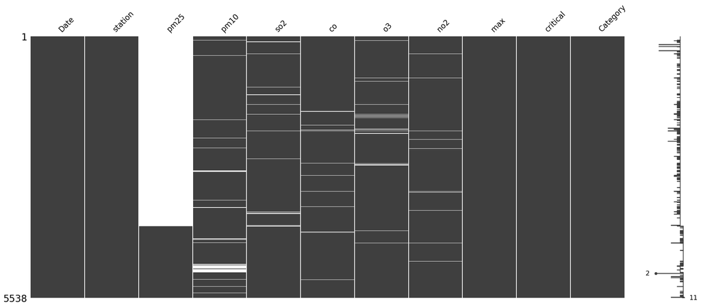

```python
### by using visualization here we find missing values

msn.matrix(df)
```

- **Most columns have good completeness.**
- **pm25 is highly incomplete and requires careful handling.**
- **Columns like station, max, and critical have almost no missing values.**
- **Moderate missing values in other pollutant columns can be filled appropriately.**

##### **6). Understand categories**

```python
df.dtypes
```

```
Date        datetime64[ns]
station             object
pm25               float64
pm10               float64
so2                float64
co                 float64
o3                 float64
no2                float64
max                float64
critical            object
Category          category
dtype: object
```

```python
cat_col = df.select_dtypes(include=['category','object']).columns ## These are the object,category type columns
```

```python
num_cols = df.select_dtypes(exclude=['category','object','datetime64[ns]']).columns ## These are the Numerical columns
```

```python
print("categorical columns are:",cat_col)
```

```
categorical columns are: Index(['station', 'critical', 'Category'], dtype='object')
```

```python
print("Numerical columns are:",num_col)
```

```
Numerical columns are: Index(['pm25', 'pm10', 'so2', 'co', 'o3', 'no2', 'max'], dtype='object')
```

#### **1).What is the shape of your dataset (rows and columns)?**

A). 5538 rows and 11 columns,This means there are 5538 observations and 11 features in the dataset.

#### **2).Which columns contain missing values?**

A). pm25 has the highest missing values (very incomplete).

All other pollutant columns have moderate missing values.

stasiun, max, and critical have very few missing entries.

#### **3).What are the data types of each column?**

```python
df.dtypes
```

```
Date        datetime64[ns]
station             object
pm25               float64
pm10               float64
so2                float64
co                 float64
o3                 float64
no2                float64
max                float64
critical            object
Category          category
dtype: object
```

7 columns are numerical (float64): pm25, pm10, so2, co, o3, no2, max

#### **4).What is the distribution of key fields**

**A).Gender / Category columns**

**B).Target variable (if applicable)**

In this dataset, the target variable is the Category column, which reflects our analysis by representing the final air-quality classification in clear English after converting the original Indonesian category labels. This translated target variable provides a more consistent and interpretable basis for further exploration and modeling.

**C).Any important identifiers or scores**

The important identifiers in this dataset include the Date and Station fields, which specify when and where each measurement was recorded. The key score is the max value, representing the highest pollutant index and playing a central role in determining the final air-quality classification.

### **Phase 2: Data Cleaning & Manipulation**

#### **1).Handle Missing Data**

```python
df.isna().sum()
```

```
Date           0
station        1
pm25        4022
pm10         315
so2          130
co            88
o3           104
no2          106
max            1
critical       4
Category       4
dtype: int64
```

```python
#miss = df.isnull().mean(axis = 1) * 100
```

```python
#df = df[miss <= 50].copy() ## Remove Rows With >50% Missing Values
```

```python
#df
```

- **Since the dataset does not contain any rows with more than 50% missing values, no rows were removed at the row level. Missing data handling was therefore performed column-wise by imputing numeric pollutant columns with the median and categorical columns with the mode.**

```python
## Handling numerical columns

numeric_cols = ['pm25','pm10','so2','co','o3','no2','max']

for col in numeric_cols:
    df[col] = df[col].fillna(df[col].median())

## handling cat columns
cat_cols = df.select_dtypes(include=['object', 'category']).columns

for col in cat_cols:
    df[col] = df[col].fillna(df[col].mode()[0])
```

- **Missing values in the numeric pollutant columns (PM10, PM2.5, CO, SO2, NO2, O3) were imputed using the median to preserve the data distribution. Outliers were not removed because the high pollution spikes represent real environmental events and contain meaningful information for air-quality analysis.**

```python
df.isna().sum()
```

```
Date        0
station     0
pm25        0
pm10        0
so2         0
co          0
o3          0
no2         0
max         0
critical    0
Category    0
dtype: int64
```

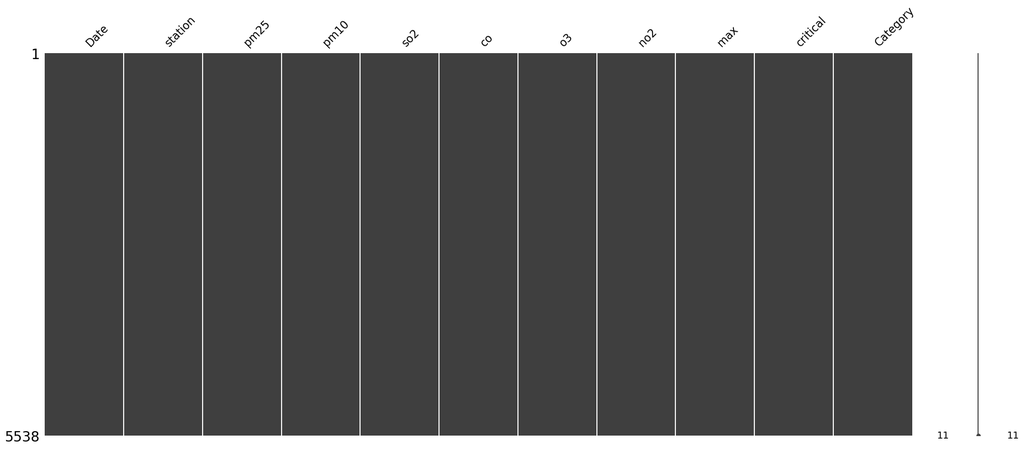

```python
msn.matrix(df) ## Misiing values are handled
```

**The Category column does not contain any missing values, as the total number of NaN entries is zero.**

- **Missing value handling has been successfully completed. All null or incomplete records in the dataset were identified and treated appropriately to ensure clean and reliable data for further analysis.**

#### **2). Remove Duplicates**

```python
df.duplicated().sum()
```

```
np.int64(0)
```

**The duplicate check returned a value of 0, which means the dataset does not contain any duplicate records.**

#### **3) Fix Inconsistencies in Categorical Data**

```python
df['Category'].nunique()
```

```
5
```

```python
len(df['Category'].unique())
```

```
5
```

```python
df['Category'].nunique() == len(df['Category'].unique())
```

```
True
```

```python
df = df[df['Category'].isin(['GOOD', 'MODERATE', 'UNHEALTHY', 'VERY UNHEALTHY', 'HAZARDOUS'])]
```

- **There is no Inconsistencies in Categorical Data**

#### **Outliers**

```python
num_cols = ['pm10', 'pm25', 'co', 'so2', 'no2', 'o3','max']

for col in num_cols:
    Q1 = df[col].quantile(0.25)
    Q3 = df[col].quantile(0.75)
    IQR = Q3 - Q1

    lower = Q1 - 1.5 * IQR
    upper = Q3 + 1.5 * IQR

    outliers = df[(df[col] < lower) | (df[col] > upper)][col]

    print(f"\n=== Outliers in {col} ===")
    print(f"Count: {len(outliers)}")
    print(outliers.head())
```

```
=== Outliers in pm10 ===
Count: 242
308     13.0
312     14.0
467     15.0
531    110.0
532    105.0
Name: pm10, dtype: float64

=== Outliers in pm25 ===
Count: 1494
4018    58.0
4019    86.0
4020    93.0
4021    49.0
4022    89.0
Name: pm25, dtype: float64

=== Outliers in co ===
Count: 240
0     73.0
7     51.0
19    63.0
21    45.0
23    46.0
Name: co, dtype: float64

=== Outliers in so2 ===
Count: 46
2936    72.0
2937    70.0
4120    63.0
4159    62.0
4295    67.0
Name: so2, dtype: float64

=== Outliers in no2 ===
Count: 198
145     34.0
166     38.0
1166    37.0
1960    63.0
1962    42.0
Name: no2, dtype: float64

=== Outliers in o3 ===
Count: 189
313    215.0
321    206.0
325    238.0
357    241.0
648    208.0
Name: o3, dtype: float64

=== Outliers in max ===
Count: 292
313    215.0
321    206.0
323    195.0
325    238.0
328    190.0
Name: max, dtype: float64
```

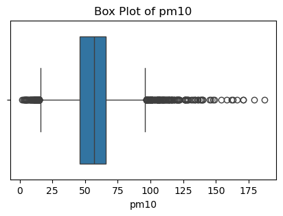

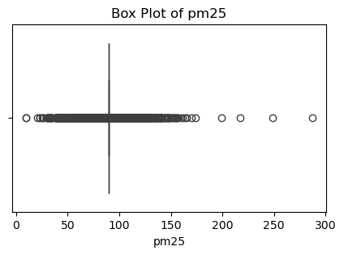

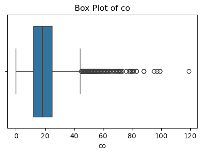

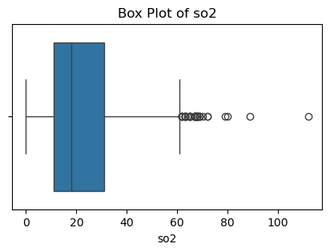

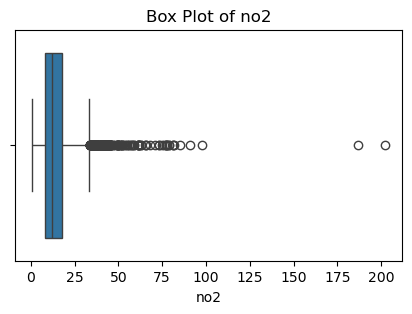

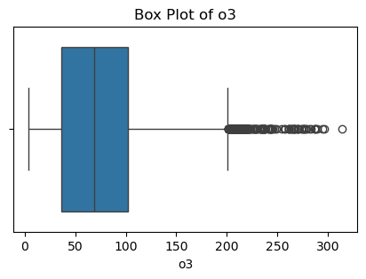

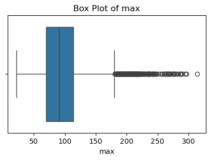

```python
num_cols = ['pm10', 'pm25', 'co', 'so2', 'no2', 'o3', 'max']

for col in num_cols:
    plt.figure(figsize=(5,3))
    sns.boxplot(x=df[col])
    plt.title(f'Box Plot of {col}')
    plt.xlabel(col)
    plt.show()
```

- **Outliers were not removed because the extreme pollutant values in this air-quality dataset represent real environmental events such as pollution spikes, industrial emissions, or festival-related increases. These values carry meaningful information for analysis and prediction, and removing them would distort the true behavior of air-quality patterns. Only impossible or invalid values (e.g., negative or corrupted readings) should be treated as errors.**

## **Univariate Analysis**

```python
df.columns
```

```
Index(['Date', 'station', 'pm25', 'pm10', 'so2', 'co', 'o3', 'no2', 'max',
       'critical', 'Category'],
      dtype='object')
```

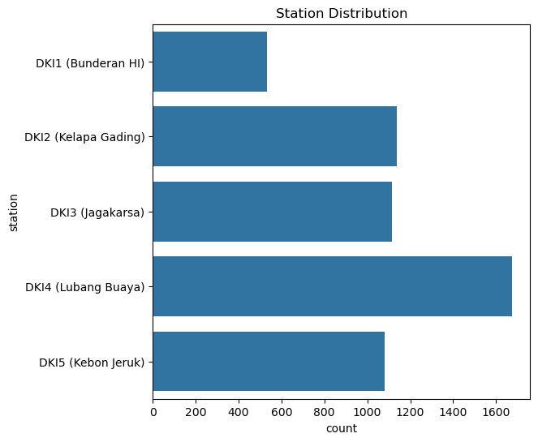

```python
### Univariate Analysis on Station

plt.figure(figsize = (6,6))
sns.countplot(df["station"])
plt.title("Station Distribution")
plt.show()
```

- **DKI4 (Lubang Buaya) has the highest number of observations, indicating it is the most represented station in the dataset.**

**DKI1 (Bundaran HI) shows the lowest count, while the remaining stations have relatively balanced but moderate distributions.**

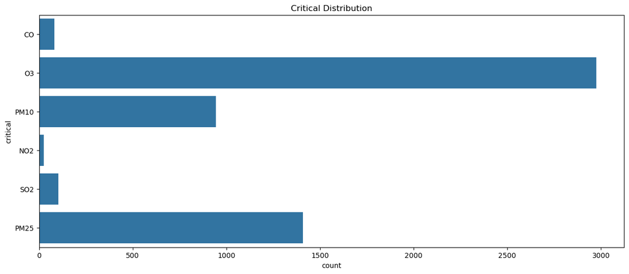

```python
### Univariate Analysis on Critical column

plt.figure(figsize = (15,6))
sns.countplot(df["critical"])
plt.title("Critical Distribution")
plt.show()
```

- **O₃ (Ozone) is the most frequently recorded critical pollutant by a large margin, indicating it is the dominant air-quality concern in the dataset.**

**PM2.5 and PM10 also show significant critical counts, while CO, NO₂, and SO₂ occur comparatively rarely at critical levels.**

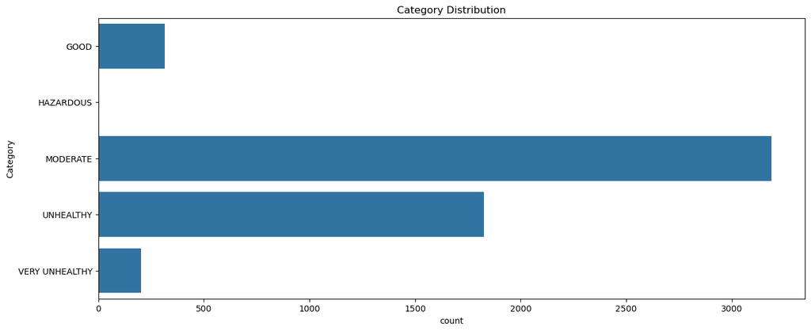

```python
### Univariate Analysis on Categorical column

plt.figure(figsize = (15,6))
sns.countplot(df["Category"])
plt.title("Category Distribution")
plt.show()
```

- **Moderate air quality dominates the dataset, followed by a substantial number of Unhealthy observations, indicating frequent pollution concerns.**

**Very Unhealthy and Good categories occur far less often, while Hazardous cases are almost negligible.**

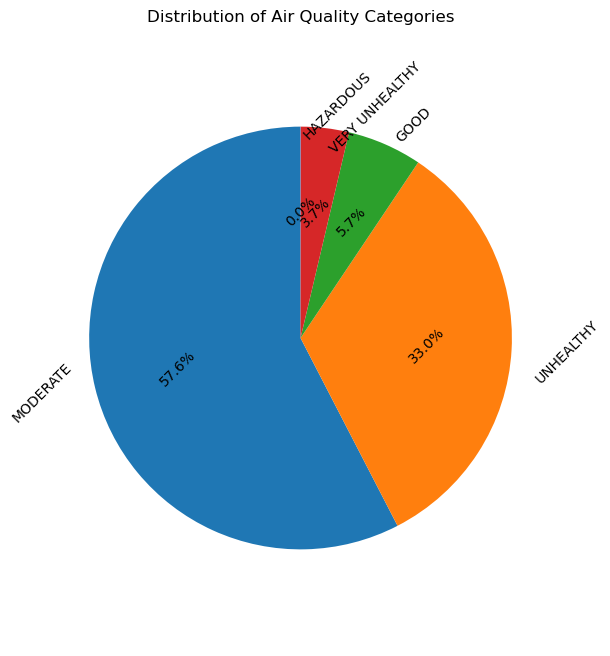

```python
## Univariate analysis on Categorical column

category_counts = df['Category'].value_counts()

# Pie chart
plt.figure(figsize=(6,8))
plt.pie(
    category_counts,
    labels=category_counts.index,
    autopct='%1.1f%%',
    startangle=90,
    textprops={'rotation': 45}
)
plt.title('Distribution of Air Quality Categories')
plt.axis('equal')  # Makes pie a circle
plt.show()
```

- **The dataset is heavily skewed toward MODERATE and UNHEALTHY air-quality categories, indicating persistent air pollution issues, while truly clean-air days are relatively rare and extreme pollution events occur infrequently but pose serious health risks.**

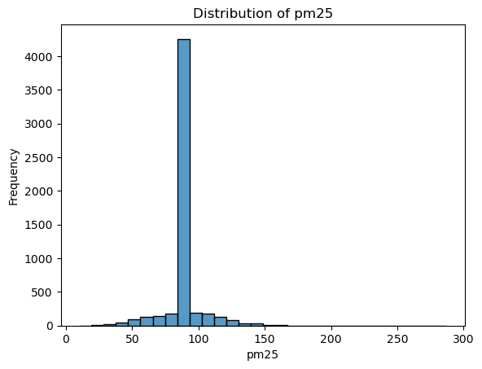

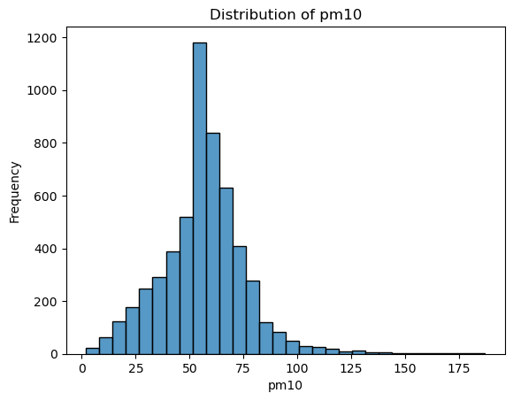

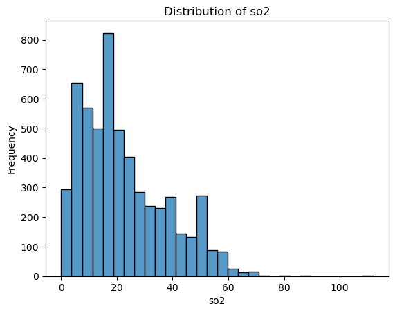

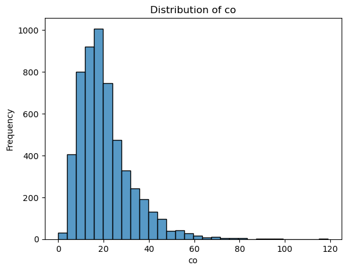

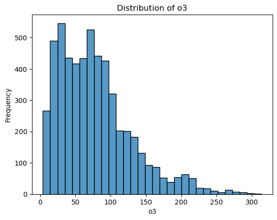

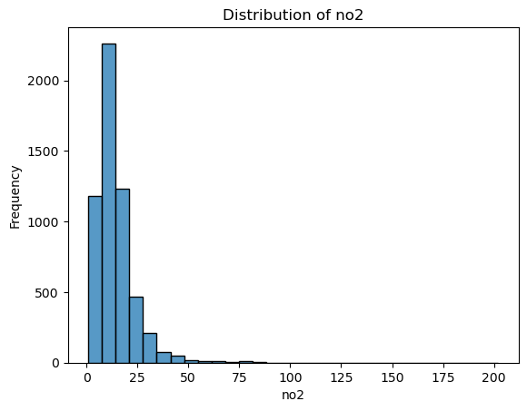

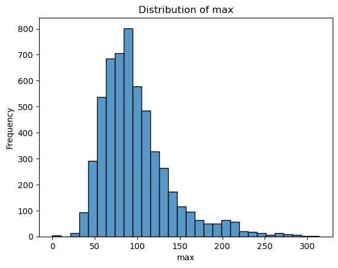

```python
for col in num_cols:
    plt.figure()
    sns.histplot(df[col], bins=30)
    plt.title(f'Distribution of {col}')
    plt.xlabel(col)
    plt.ylabel('Frequency')
    plt.show()
```

## **Visual & Non - Visual Bivariate Analysis**

#### **1). Categorical vs Categorical**

```python
ct = pd.crosstab(df['Category'], df['station'], normalize='index') * 100
ct['Row_Total'] = ct.sum(axis=1)
```

```python
ct
```

| station Category | DKI1 (Bunderan HI) | DKI2 (Kelapa Gading) | DKI3 (Jagakarsa) | DKI4 (Lubang Buaya) | DKI5 (Kebon Jeruk) | Row_Total |
| --- | --- | --- | --- | --- | --- | --- |
| GOOD | 45.253165 | 20.886076 | 12.025316 | 15.506329 | 6.329114 | 100.0 |
| HAZARDOUS | 0.000000 | 100.000000 | 0.000000 | 0.000000 | 0.000000 | 100.0 |
| MODERATE | 11.142498 | 16.038920 | 23.791588 | 31.669805 | 17.357188 | 100.0 |
| UNHEALTHY | 1.587302 | 22.276957 | 17.022441 | 33.333333 | 25.779967 | 100.0 |
| VERY UNHEALTHY | 0.000000 | 74.876847 | 4.433498 | 3.448276 | 17.241379 | 100.0 |

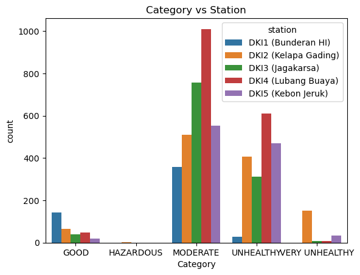

```python
### cat vs cat using visualization

sns.countplot(x='Category', hue='station', data=df)
plt.title("Category vs Station")
plt.show()
```

Overall, air quality varies sharply by station, with DKI1 being the cleanest location and DKI2 emerging as the dominant pollution hotspot.

#### **2). Categorical vs Numerical**

```python
cols = ['pm10', 'pm25', 'co', 'so2', 'no2', 'o3']

for col in cols:
    print(f"\n=== Category vs {col} ===")
    print(df.groupby('Category')[col].agg(['mean', 'median', 'min', 'max', 'std']))
```

```
=== Category vs pm10 ===
                     mean  median   min    max        std
Category
GOOD            34.702532    35.0   5.0   57.0  11.269574
HAZARDOUS       73.000000    73.0  73.0   73.0        NaN
MODERATE        53.756511    56.0   2.0  100.0  17.137722
UNHEALTHY       64.253421    62.0   5.0  187.0  20.541781
VERY UNHEALTHY  62.014778    62.0  18.0  163.0  16.434833

=== Category vs pm25 ===
                     mean  median   min    max        std
Category
GOOD            85.104430    90.0  26.0   90.0  14.319434
HAZARDOUS       90.000000    90.0  90.0   90.0        NaN
MODERATE        85.894258    90.0  10.0  103.0  11.018181
UNHEALTHY       97.549535    90.0  58.0  199.0  14.332506
VERY UNHEALTHY  92.206897    90.0  55.0  287.0  19.957295

=== Category vs co ===
                     mean  median   min    max        std
Category
GOOD            17.446203    15.0   2.0   50.0  11.036460
HAZARDOUS       28.000000    28.0  28.0   28.0        NaN
MODERATE        20.201757    17.0   0.0   99.0  12.701573
UNHEALTHY       20.974822    19.0   1.0  119.0  10.575107
VERY UNHEALTHY  22.517241    20.0   3.0   69.0   9.877640

=== Category vs so2 ===
                     mean  median   min    max        std
Category
GOOD            17.310127    15.0   0.0   69.0  15.892457
HAZARDOUS       15.000000    15.0  15.0   15.0        NaN
MODERATE        23.169438    18.0   0.0   89.0  16.063888
UNHEALTHY       22.410509    20.0   0.0  112.0  14.069459
VERY UNHEALTHY  16.418719    17.0   0.0   51.0   7.916460

=== Category vs no2 ===
                     mean  median   min    max        std
Category
GOOD            10.784810    10.0   1.0   61.0   7.742147
HAZARDOUS       16.000000    16.0  16.0   16.0        NaN
MODERATE        14.138375    12.0   1.0   98.0  10.011669
UNHEALTHY       15.110016    13.0   2.0  187.0   9.525342
VERY UNHEALTHY  15.172414    15.0   2.0  202.0  14.066843

=== Category vs o3 ===
                      mean  median    min    max        std
Category
GOOD             31.667722    32.5    4.0   69.0  13.358085
HAZARDOUS       314.000000   314.0  314.0  314.0        NaN
MODERATE         57.344211    60.0    4.0  100.0  26.722901
UNHEALTHY       103.836344   113.0    6.0  199.0  49.388606
VERY UNHEALTHY  221.985222   216.0   20.0  297.0  37.183979
```

[output not shown]

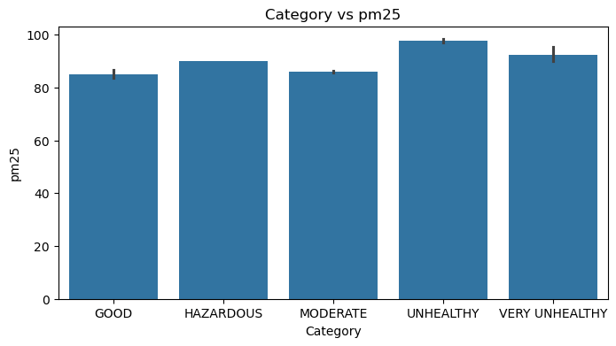

```python
print(num_cols)

plt.figure(figsize=(8,4))
sns.barplot(x='Category', y='pm25', data=df)
plt.title(f'Category vs pm25')
plt.show()
```

**PM10 Analysis**

GOOD category has the lowest PM10 levels (mean ≈ 34), indicating clean air.

MODERATE category shows mid-range PM10 values (mean ≈ 53), with wider variation.

UNHEALTHY and VERY UNHEALTHY categories record significantly higher PM10 levels, showing strong dust/particle pollution.

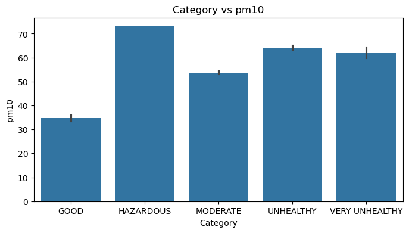

```python
plt.figure(figsize=(8,4))
sns.barplot(x='Category', y='pm10', data=df)
plt.title(f'Category vs pm10')
plt.show()
```

**PM25 Analysis**

GOOD category shows lower PM25, though slightly higher than PM10 in some cases.

MODERATE and UNHEALTHY categories show progressively increasing PM25, indicating rising fine-particle pollution.

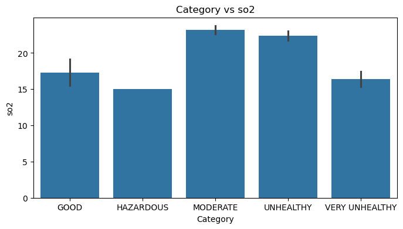

```python
plt.figure(figsize=(8,4))
sns.barplot(x='Category', y='so2', data=df)
plt.title(f'Category vs so2')
plt.show()
```

**SO2 Analysis**

SO2 levels remain low in the GOOD category.

Moderate increases appear in the MODERATE and UNHEALTHY categories, showing the influence of industrial or combustion sources.

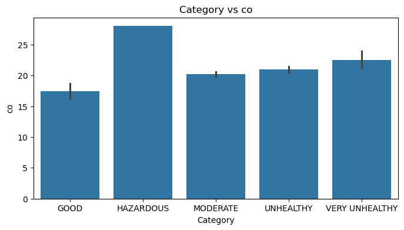

```python
plt.figure(figsize=(8,4))
sns.barplot(x='Category', y='co', data=df)
plt.title(f'Category vs co')
plt.show()
```

**CO Analysis**

CO is very low in the GOOD category, indicating minimal combustion or vehicle-related pollution.

MODERATE and UNHEALTHY categories show slightly higher CO, though still within lower ranges.

VERY UNHEALTHY category shows a noticeable increase in CO, indicating degraded air quality.

HAZARDOUS category includes one elevated CO reading, reflecting a severe pollution event.

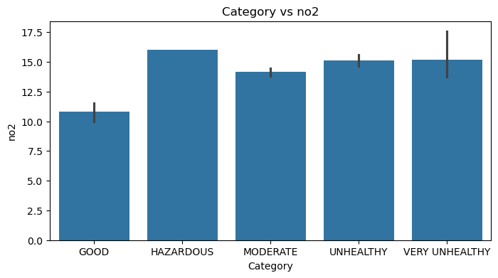

```python
plt.figure(figsize=(8,4))
sns.barplot(x='Category', y='no2', data=df)
plt.title(f'Category vs no2')
plt.show()
```

**NO2 Analysis**

NO2 is lowest in the GOOD category, showing minimal traffic or industrial emissions.

MODERATE and UNHEALTHY categories show rising NO2, indicating worsening air conditions.

VERY UNHEALTHY category displays elevated NO2, consistent with high pollution.

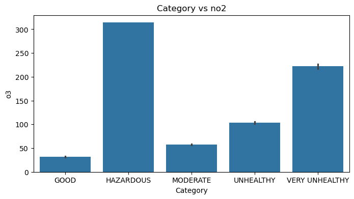

```python
plt.figure(figsize=(8,4))
sns.barplot(x='Category', y='o3', data=df)
plt.title(f'Category vs no2')
plt.show()
```

**O3 Analysis**

GOOD and MODERATE categories show low to moderate O3 levels.

UNHEALTHY and VERY UNHEALTHY categories show a clear rise in O3, indicating stronger photochemical reactions.

HAZARDOUS category exhibits extremely high O3 levels, confirming severe air-quality deterioration.

#### **4). Numerical vs Numerical**

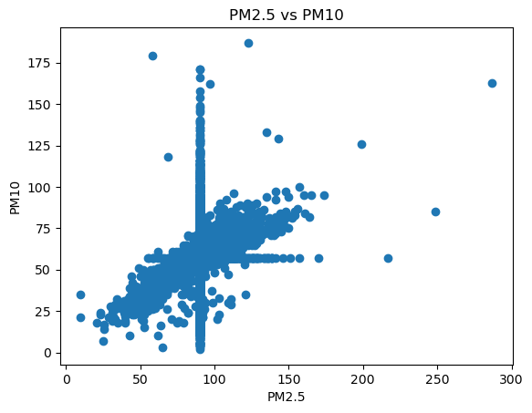

```python
##PM2.5 vs PM10
plt.scatter(df['pm25'], df['pm10'])
plt.xlabel('PM2.5')
plt.ylabel('PM10')
plt.title('PM2.5 vs PM10')
plt.show()
```

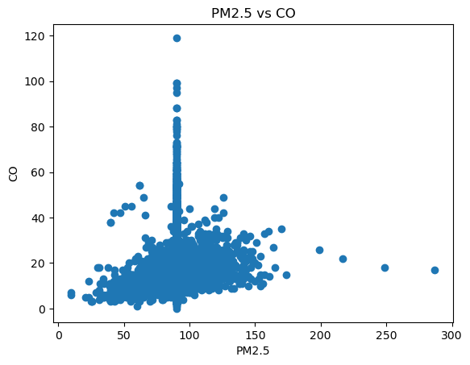

```python
## PM2.5 vs CO
plt.scatter(df['pm25'], df['co'])
plt.xlabel('PM2.5')
plt.ylabel('CO')
plt.title('PM2.5 vs CO')
plt.show()
```

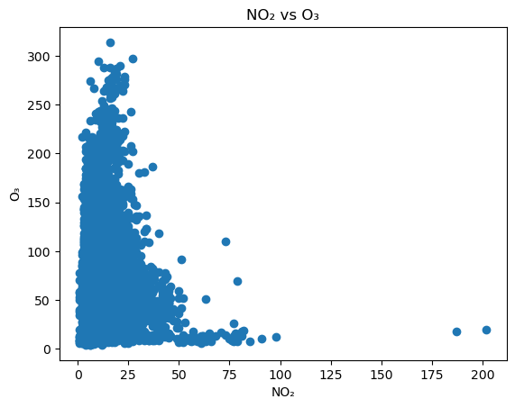

```python
## NO₂ vs O₃

plt.scatter(df['no2'], df['o3'])
plt.xlabel('NO₂')
plt.ylabel('O₃')
plt.title('NO₂ vs O₃')
plt.show()
```

**NO₂ vs O₃: The relationship appears weak to slightly inverse, reflecting complex photochemical reactions in the atmosphere rather than a direct linear association.**

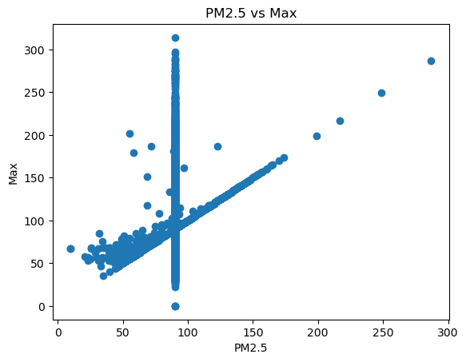

```python
## PM2.5 vs Max

plt.scatter(df['pm25'], df['max'])
plt.xlabel('PM2.5')
plt.ylabel('Max')
plt.title('PM2.5 vs Max')
plt.show()
```

**PM2.5 vs Max: A strong correlation indicates that PM2.5 is a major contributor to overall air-quality severity and plays a key role in driving high pollution index values.**

## **Visual Multivariate Analysis**

```python
numeric_cols = ['pm10', 'pm25', 'co', 'so2', 'no2', 'o3']

corr_matrix = df[numeric_cols].corr()
print("=== Numerical vs Numerical (Correlation Matrix) ===")
print(corr_matrix)
```

```
=== Numerical vs Numerical (Correlation Matrix) ===
          pm10      pm25        co       so2       no2        o3
pm10  1.000000  0.328830  0.091524  0.015228  0.139866  0.098758
pm25  0.328830  1.000000  0.139888 -0.033977  0.049733  0.059716
co    0.091524  0.139888  1.000000 -0.269676  0.086042  0.110267
so2   0.015228 -0.033977 -0.269676  1.000000  0.422077 -0.348335
no2   0.139866  0.049733  0.086042  0.422077  1.000000 -0.186650
o3    0.098758  0.059716  0.110267 -0.348335 -0.186650  1.000000
```

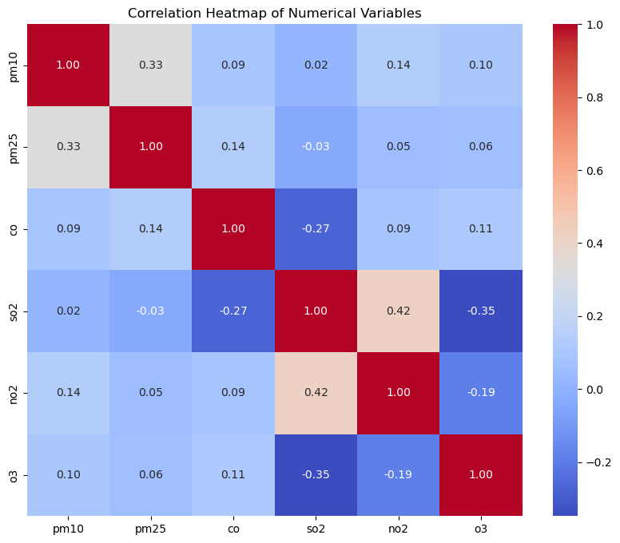

```python
plt.figure(figsize=(10, 8))
sns.heatmap(corr, annot=True, cmap='coolwarm', fmt='.2f')
plt.title('Correlation Heatmap of Numerical Variables')
plt.show()
```

- Most pollutant pairs show weak or near-zero correlations, meaning they behave independently in this dataset.
- PM10 and PM25 have a weak positive correlation, indicating they sometimes increase together but not strongly.
- SO₂ and NO₂ show the strongest positive correlation, suggesting both pollutants commonly originate from similar industrial or combustion sources.
- SO₂ and O₃ have a moderate negative correlation, reflecting known atmospheric chemistry where higher SO₂ levels reduce ozone formation.
- CO shows weak or negligible correlations with all other pollutants, implying it is influenced by different pollution sources, mainly combustion.
- NO₂ and O₃ also show a weak negative correlation, consistent with their inverse chemical relationship in the atmosphere.
- No pollutant pair shows a strong positive or strong negative correlation, indicating the dataset does not contain tightly linked pollutant behaviors.

Overall, the numerical–numerical analysis confirms that air pollutants in this dataset mostly vary independently, with only a few moderate relationships driven by chemical or source-based factors.

### **Conclusion:**

**This project successfully performed an in-depth exploratory data analysis of the ISPU air quality dataset for DKI Jakarta, providing a clear understanding of pollution characteristics and behavior. Through statistical analysis and visual exploration, key relationships among major pollutants were identified, along with notable trends, correlations, and extreme pollution events.**

**The analysis revealed that particulate matter and certain gaseous pollutants exhibit meaningful associations, while outlier detection highlighted periods of unusually high pollution levels that may pose serious health risks. These insights emphasize the importance of continuous air-quality monitoring and data-driven evaluation of environmental conditions.**

**Overall, the project demonstrates a structured and professional EDA workflow, offering valuable insights for environmental analysis and establishing a strong foundation for future predictive modeling and air-quality management initiatives.**